# 1. Load and inspect the data

We will use a dataset that contains images of hands in poses corresponding to letters in Amercian Sign Language. Each image is small (similar to MNIST size) and we will build a CNN classifier (using Keras) to determine the corresponding letter for an image.

1. Load the dataset, look at examples of the images and the summary statistics and information for the class labels.

```python
# Importing modules
import random
import pandas as pd
import numpy as np
import matplotlib.pyplot as plt
import seaborn as sn
import tensorflow as tf
from tensorflow import keras
from numpy.random import seed
from sklearn.preprocessing import LabelEncoder
from tensorflow.keras.utils import set_random_seed
from sklearn.linear_model import LinearRegression
from sklearn import metrics
from sklearn.metrics import confusion_matrix
from sklearn.metrics import ConfusionMatrixDisplay
from sklearn.metrics import multilabel_confusion_matrix
from sklearn.model_selection import train_test_split
%matplotlib inline

# Making reproducible
random.seed(1)
np.random.seed(1)
tf.random.set_seed(1)

# Importing data
train_path = r"C:\Users\Dylan Rohan\OneDrive\Documents\Data science\Using Machine Learning Tools PG\slmnist\sign_mnist_train.csv"
test_path = r"C:\Users\Dylan Rohan\OneDrive\Documents\Data science\Using Machine Learning Tools PG\slmnist\sign_mnist_test.csv"
train_set = pd.read_csv(train_path)
test_set = pd.read_csv(test_path)
```

```python
# Observing data frames
train_set.head()
```

|  | label | pixel1 | pixel2 | pixel3 | pixel4 | pixel5 | pixel6 | pixel7 | pixel8 | pixel9 | ... | pixel775 | pixel776 | pixel777 | pixel778 | pixel779 | pixel780 | pixel781 | pixel782 | pixel783 | pixel784 |
| --- | --- | --- | --- | --- | --- | --- | --- | --- | --- | --- | --- | --- | --- | --- | --- | --- | --- | --- | --- | --- | --- |
| 0 | 3 | 107 | 118 | 127 | 134 | 139 | 143 | 146 | 150 | 153 | ... | 207 | 207 | 207 | 207 | 206 | 206 | 206 | 204 | 203 | 202 |
| 1 | 6 | 155 | 157 | 156 | 156 | 156 | 157 | 156 | 158 | 158 | ... | 69 | 149 | 128 | 87 | 94 | 163 | 175 | 103 | 135 | 149 |
| 2 | 2 | 187 | 188 | 188 | 187 | 187 | 186 | 187 | 188 | 187 | ... | 202 | 201 | 200 | 199 | 198 | 199 | 198 | 195 | 194 | 195 |
| 3 | 2 | 211 | 211 | 212 | 212 | 211 | 210 | 211 | 210 | 210 | ... | 235 | 234 | 233 | 231 | 230 | 226 | 225 | 222 | 229 | 163 |
| 4 | 13 | 164 | 167 | 170 | 172 | 176 | 179 | 180 | 184 | 185 | ... | 92 | 105 | 105 | 108 | 133 | 163 | 157 | 163 | 164 | 179 |

5 rows × 785 columns

```python
test_set.head()
```

|  | label | pixel1 | pixel2 | pixel3 | pixel4 | pixel5 | pixel6 | pixel7 | pixel8 | pixel9 | ... | pixel775 | pixel776 | pixel777 | pixel778 | pixel779 | pixel780 | pixel781 | pixel782 | pixel783 | pixel784 |
| --- | --- | --- | --- | --- | --- | --- | --- | --- | --- | --- | --- | --- | --- | --- | --- | --- | --- | --- | --- | --- | --- |
| 0 | 6 | 149 | 149 | 150 | 150 | 150 | 151 | 151 | 150 | 151 | ... | 138 | 148 | 127 | 89 | 82 | 96 | 106 | 112 | 120 | 107 |
| 1 | 5 | 126 | 128 | 131 | 132 | 133 | 134 | 135 | 135 | 136 | ... | 47 | 104 | 194 | 183 | 186 | 184 | 184 | 184 | 182 | 180 |
| 2 | 10 | 85 | 88 | 92 | 96 | 105 | 123 | 135 | 143 | 147 | ... | 68 | 166 | 242 | 227 | 230 | 227 | 226 | 225 | 224 | 222 |
| 3 | 0 | 203 | 205 | 207 | 206 | 207 | 209 | 210 | 209 | 210 | ... | 154 | 248 | 247 | 248 | 253 | 236 | 230 | 240 | 253 | 255 |
| 4 | 3 | 188 | 191 | 193 | 195 | 199 | 201 | 202 | 203 | 203 | ... | 26 | 40 | 64 | 48 | 29 | 46 | 49 | 46 | 46 | 53 |

5 rows × 785 columns

```python
# Observing data characteristics
## Shape
print("The training set is of the shape", train_set.shape, " Indicating there are ", train_set.shape[0], "pictures," +
      " each with a label and", (train_set.shape[1]-1), "pixels")

print("The test set is of the shape", test_set.shape, " Indicating there are ", test_set.shape[0], "pictures," +
      " each with a label and", (test_set.shape[1]-1), "pixels")

## Data allocation
total_images = train_set.shape[0] + test_set.shape[0]
percentage_split = round(train_set.shape[0]/total_images, 3)
print("The training set holds", percentage_split*100, "% of the images, representing a near 80:20 split")

## Other important checks
### Training set
empty_row = train_set.isna().sum()
for value in empty_row:
    if value != 0:
        print("There is a row containing NA values")
duplicate_row = train_set.duplicated().sum()
for value in empty_row:
    if value != 0:
        print("There is a duplicated row")

### Testing set
empty_row = test_set.isna().sum()
for value in empty_row:
    if value != 0:
        print("There is a row containing NA values")
duplicate_row = test_set.duplicated().sum()
for value in empty_row:
    if value != 0:
        print("There is a duplicated row")
```

```
The training set is of the shape (27455, 785)  Indicating there are  27455 pictures, each with a label and 784 pixels
The test set is of the shape (7172, 785)  Indicating there are  7172 pictures, each with a label and 784 pixels
The training set holds 79.3 % of the images, representing a near 80:20 split
```

```python
# Obtaining samples
classes = train_set['label'].value_counts()
classes = pd.DataFrame(classes)
classes = classes.reset_index()
classes.rename(columns = {'index':'label', 'label':'frequency'}, inplace = True)
classes.sort_values(by = 'label', inplace=True)
classes.reset_index(drop=True, inplace=True)
print("As you can see there are only 24 labels, meaning two letters are missing. These are J and Z as they require motion.")
print("There is good represntation of all images, with E having the fewest at 957 images")
classes
```

```
As you can see there are only 24 labels, meaning two letters are missing. These are J and Z as they require motion.
There is good represntation of all images, with E having the fewest at 957 images
```

|  | label | frequency |
| --- | --- | --- |
| 0 | 0 | 1126 |
| 1 | 1 | 1010 |
| 2 | 2 | 1144 |
| 3 | 3 | 1196 |
| 4 | 4 | 957 |
| 5 | 5 | 1204 |
| 6 | 6 | 1090 |
| 7 | 7 | 1013 |
| 8 | 8 | 1162 |
| 9 | 10 | 1114 |
| 10 | 11 | 1241 |
| 11 | 12 | 1055 |
| 12 | 13 | 1151 |
| 13 | 14 | 1196 |
| 14 | 15 | 1088 |
| 15 | 16 | 1279 |
| 16 | 17 | 1294 |
| 17 | 18 | 1199 |
| 18 | 19 | 1186 |
| 19 | 20 | 1161 |
| 20 | 21 | 1082 |
| 21 | 22 | 1225 |
| 22 | 23 | 1164 |
| 23 | 24 | 1118 |

1. Scale the image values appropriately.

There are pixel values between 0 and 255, so I'm scaling them so they are instead between 0 and 1 by dividing each by the maximum of 255.

```python
# Preprocessing
train_set.iloc[:,1:] = train_set.iloc[:,1:]/255
test_set.iloc[:,1:] = test_set.iloc[:,1:]/255

## Confirming alteration
train_set.max()
```

```
label       24.0
pixel1       1.0
pixel2       1.0
pixel3       1.0
pixel4       1.0
            ...
pixel780     1.0
pixel781     1.0
pixel782     1.0
pixel783     1.0
pixel784     1.0
Length: 785, dtype: float64
```

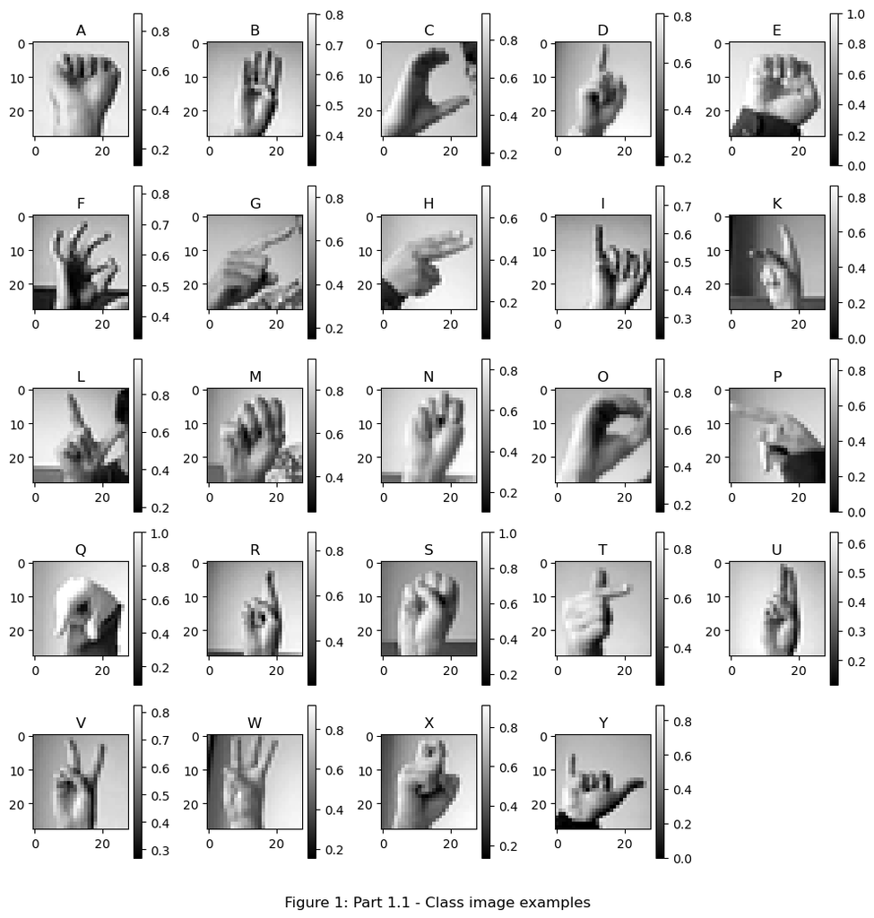

```python
# Displaying example images
## Acquiring samples of each class
class_label = classes['label'].tolist()
samples = {}
title = {'1': 'A', '2':'B', '3':'C', '4':'D', '5':'E', '6':'F', '7':'G', '8': 'H', '9':'I', '10':'K',
         '11': 'L', '12':'M', '13':'N', '14':'O', '15':'P', '16':'Q', '17':'R', '18':'S', '19': 'T', '20':'U',
        '21':'V', '22': 'W', '23':'X', '24':'Y'}

for item in class_label:
    if item not in samples.keys():
        index = np.where(train_set['label'] == item)[0][0]
        samples[item] = index

## displaying first instance of each class
position = 1
plt.figure(figsize = [10, 10])
for class_, index in samples.items():
    plt.subplot(5, 5, position)
    plt.imshow(train_set.iloc[index, 1:].values.reshape(28,28), cmap='gray')
    plt.grid(False)
    plt.title(title[str(position)])
    plt.colorbar()
    plt.tight_layout()
    position += 1
plt.suptitle("Figure 1: Part 1.1 - Class image examples",x = 0.5, y = -.02)
```

1. Deal with missing labels by either making sure that the label values are continuous or converting to a representation where the numerical label values do not matter.

```python
# Setting the labels to be continuous inorder to keep softmax activation and categorical cross entropy loss funtion
label_encoder = LabelEncoder()

train_set['label'] = label_encoder.fit_transform(train_set['label'])
test_set['label'] = label_encoder.fit_transform(test_set['label'])
print("Checking the label columns have been converted properly:\nTrain Set\n", train_set.dtypes)
print("\nTest set\n", test_set.dtypes)
```

```
Checking the label columns have been converted properly:
Train Set
 label         int64
pixel1      float64
pixel2      float64
pixel3      float64
pixel4      float64
             ...
pixel780    float64
pixel781    float64
pixel782    float64
pixel783    float64
pixel784    float64
Length: 785, dtype: object

Test set
 label         int64
pixel1      float64
pixel2      float64
pixel3      float64
pixel4      float64
             ...
pixel780    float64
pixel781    float64
pixel782    float64
pixel783    float64
pixel784    float64
Length: 785, dtype: object
```

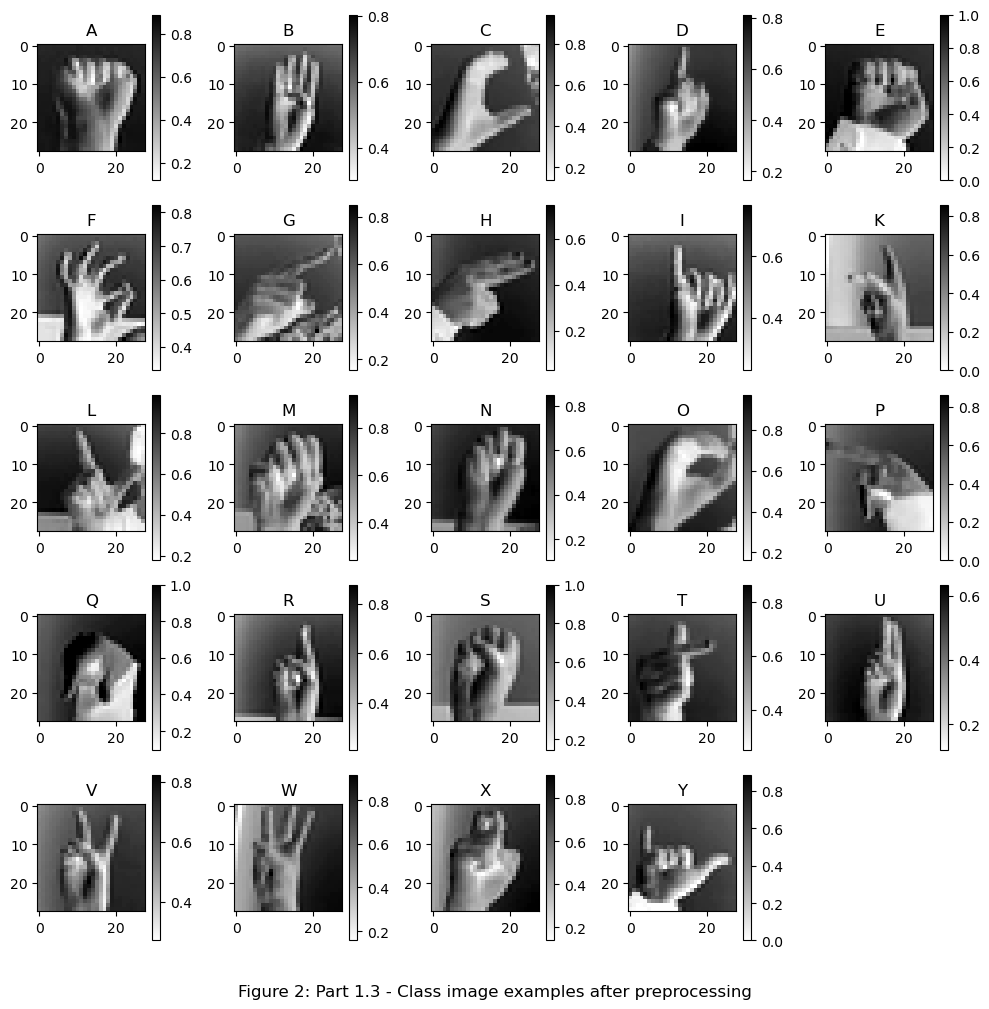

```python
# Observing Impact of preprocessing
## displaying first instance of each class
position = 1

plt.figure(figsize = [10, 10])
for class_, index in samples.items():
    plt.subplot(5,5,position)
    plt.imshow(train_set.iloc[index, 1:].values.astype('float32').reshape(28,28), cmap = plt.cm.binary)
    plt.grid(False)
    plt.title(title[str(position)])
    plt.colorbar()
    plt.tight_layout()
    position += 1
    plt.suptitle("Figure 2: Part 1.3 - Class image examples after preprocessing", x = 0.5, y = -.02)
```

1. Split the *test* labels and images into separate validation and testing datasets according to a 50/50 split. We will use all of the training dataset for training.

```python
# Splitting Data
x_test, x_val, y_test, y_val = train_test_split(test_set.iloc[:,1:], test_set['label'], test_size = 0.5,
                                                  stratify = test_set['label'], random_state = 1)
# Confirming output (should equal 1 if split was successful 50:50)
x_test.shape[0]/x_val.shape[0]

# Seperating training data into features and outcome + reshaping as required
x_train = train_set.drop("label",axis=1).values.reshape(-1, 28, 28, 1)
y_train = train_set['label']

x_test = x_test.values.reshape(-1, 28, 28, 1)
x_val = x_val.values.reshape(-1, 28, 28, 1)

print("Trainning data shapes: x =", x_train.shape, "& y =", y_train.shape)
print("Validation data shapes: x =", x_val.shape, "& y =", y_val.shape)
print("Trainning data shapes: x =", x_test.shape, "& y =", y_test.shape)
```

```
Trainning data shapes: x = (27455, 28, 28, 1) & y = (27455,)
Validation data shapes: x = (3586, 28, 28, 1) & y = (3586,)
Trainning data shapes: x = (3586, 28, 28, 1) & y = (3586,)
```

1. Question: Why are we splitting the test set up rather than the training set in this case? Hint: look at the description of how the dataset is constructed.

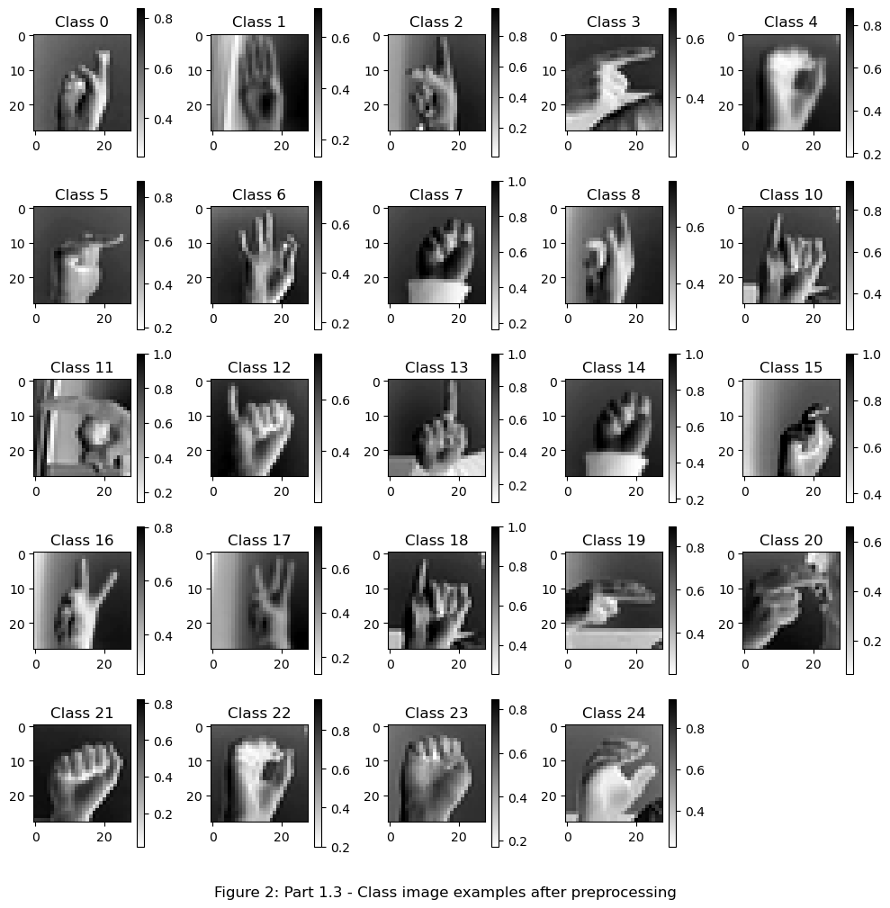

```python
# Viewing test data
position = 1
plt.figure(figsize = [10, 10])
for class_, index in samples.items():
    plt.subplot(5,5,position)
    plt.imshow(test_set.iloc[index, 1:].values.astype('float32').reshape(28,28), cmap = plt.cm.binary)
    plt.grid(False)
    plt.title("Class " + str(class_))
    plt.colorbar()
    plt.tight_layout()
    position += 1
    plt.suptitle("Figure 2: Part 1.3 - Class image examples after preprocessing", x = 0.5, y = -.02)
```

*Answer*

The test set is split to obtain a validation set because the training set contains only 27,450 instances compared to the 48,000 instances observed in assignment 2 or the standard MNIST set of 60,000. Determining how best to allocate data can be difficult as there are no hard and fast rules, however more is generally better when it comes to training and we can't risk providing the model with too little data.

There also seems to be some evdence that the test set was not prepared in the same way as the training set. The evidence available in the kaggle forum suggests that the test set was prepared seperately. If the validation set was taken from the training set the model's accuracy can reach 1, but if it is taken from the test set it can reach about 0.8. It is not explicitly outlined in the data's read me file how these were prepared, but validating from the test set gives a more realistic estiamte of accuracy.

# 2. Build and train a CNN

1. Build a CNN using Keras that has the following settings:
   - Layers: Conv32 - MaxPooling - Conv64 - MaxPooling - Conv128 - MaxPooling - Flatten - Output
     - Note that Conv32 means a convolutional layer with 32 filters, etc.
   - 3x3 kernel size,
   - ReLU activation functions for hidden layers,
   - No dropout layers,
   - BatchNorm layers in appropriate places.

```python
# Building CNN
## Initializing
cnn_model_original = keras.models.Sequential()
## Conv32
cnn_model_original.add(keras.layers.Conv2D(filters = 32, # 32 convolusion filters applied
                                  kernel_size = 3,  # 3x3 kernel/ filter size
                                  strides = 1,
                                  activation = "relu",
                                  padding = "same",   # output size should be same as input
                                  input_shape = [28, 28, 1])) # specfies input layer size, and grey scale (1)
# BatchNorm
cnn_model_original.add(keras.layers.BatchNormalization())
# MaxPooling 1
cnn_model_original.add(keras.layers.MaxPooling2D(pool_size=2)) # 2x2 pooling filter
# Conv64
cnn_model_original.add(keras.layers.Conv2D(filters = 64, kernel_size=3, strides=1, padding="same", activation="relu"))
# BatchNorm
cnn_model_original.add(keras.layers.BatchNormalization())
# MaxPooling 2
cnn_model_original.add(keras.layers.MaxPooling2D(pool_size=2))
# Conv128
cnn_model_original.add(keras.layers.Conv2D(filters = 128, kernel_size=3, strides=1, padding="same", activation="relu"))
# BatchNorm
cnn_model_original.add(keras.layers.BatchNormalization())
# MaxPooling 3
cnn_model_original.add(keras.layers.MaxPooling2D(pool_size=2))
# Flattening output
cnn_model_original.add(keras.layers.Flatten()) # Make 1d vector from 2d array
# Generate output
cnn_model_original.add(keras.layers.Dense(24, activation = "softmax")) # dense neural network architecture with 24 output classes
# Compile the model
cnn_model_original.compile(optimizer = keras.optimizers.Nadam(learning_rate = 0.01), ###### Nadam optimizer
                  loss = 'sparse_categorical_crossentropy',
                  metrics = ['accuracy'])

# Checking architecture
cnn_model_original.summary()
```

```
Model: "sequential_11"
_________________________________________________________________
 Layer (type)                Output Shape              Param #
=================================================================
 conv2d_34 (Conv2D)          (None, 28, 28, 32)        320

 batch_normalization_34 (Bat  (None, 28, 28, 32)       128
 chNormalization)

 max_pooling2d_34 (MaxPoolin  (None, 14, 14, 32)       0
 g2D)

 conv2d_35 (Conv2D)          (None, 14, 14, 64)        18496

 batch_normalization_35 (Bat  (None, 14, 14, 64)       256
 chNormalization)

 max_pooling2d_35 (MaxPoolin  (None, 7, 7, 64)         0
 g2D)

 conv2d_36 (Conv2D)          (None, 7, 7, 128)         73856

 batch_normalization_36 (Bat  (None, 7, 7, 128)        512
 chNormalization)

 max_pooling2d_36 (MaxPoolin  (None, 3, 3, 128)        0
 g2D)

 flatten_11 (Flatten)        (None, 1152)              0

 dense_11 (Dense)            (None, 24)                27672

=================================================================
Total params: 121,240
Trainable params: 120,792
Non-trainable params: 448
_________________________________________________________________
```

1. Explain the reasoning behind your choice of placement for the BatchNorm layers

*Answer*

1. Train this network using appropriate data and metrics. The following settings should be used in training:
   - Nadam optimiser,
   - Learning Rate Schedule exponential (see Module 4 Exercise),
   - Early stopping.

```python
# Setting early stopping agenda
early_stop = keras.callbacks.EarlyStopping(monitor='val_accuracy', patience = 3, restore_best_weights = True)

# Define lr schedule function.
def exp_decay(epoch, lr):
        # During the first call, initialise, otherwise use the current value.
        if not hasattr(exp_decay,'s'):
                exp_decay.s = 1
        if not hasattr(exp_decay,'eta0'):
                exp_decay.eta0 = 0.01
        return exp_decay.eta0 * (0.1**(epoch/exp_decay.s))

# Setting the decay rate
exp_decay.s = 5
exp_decay.eta0 = 0.01

# Create a callback using the learning rate scheduler
learning_rate_sched_cb = tf.keras.callbacks.LearningRateScheduler(exp_decay)
```

```python
# Determining optimal batch size
test_range = [256, 512, 1024, 2048]   # Apparently powers of two are more efficient 16, 32, 45, 64, 128,
evaluations = {}
for element in test_range:
    cnn_model_history = cnn_model_original.fit(x_train, y_train, epochs = 10, batch_size = element,
                                            validation_data = (x_val, y_val), verbose = 0,
                                            callbacks = [early_stop, learning_rate_sched_cb])
    loss, accuracy = cnn_model_original.evaluate(x_test, y_test, verbose = 0)
    evaluations[element] = accuracy
    print('done')

# Presenting output
pd.DataFrame({'Batch size' : evaluations.keys(), 'Accuracy': evaluations.values()})
```

```
done
done
done
done
```

|  | Batch size | Accuracy |
| --- | --- | --- |
| 0 | 256 | 0.957055 |
| 1 | 512 | 0.959286 |
| 2 | 1024 | 0.958171 |
| 3 | 2048 | 0.958450 |

```python
# Fitting the model on training data and validating (best batch size appears to be 512)
cnn_history = cnn_model_original.fit(x_train, y_train, epochs = 10, batch_size = 512,
                            validation_data = (x_val, y_val), verbose = 0,
                            callbacks = [early_stop, learning_rate_sched_cb])
```

1. Display the learning curves, confusion matrix and final performance values.

```
The improvement over the 5 epochs
       loss  accuracy  val_loss  val_accuracy        lr
0  0.948885  0.805063  3.059620      0.073898  0.010000
1  0.002656  0.999964  3.797201      0.159788  0.006310
2  0.001220  1.000000  4.885920      0.151422  0.003981
3  0.000911  1.000000  5.768940      0.157278  0.002512
4  0.000766  1.000000  5.866005      0.177078  0.001585
5  0.000686  1.000000  5.042109      0.227830  0.001000
6  0.000642  1.000000  3.473423      0.325432  0.000631
7  0.000614  1.000000  1.843462      0.537089  0.000398
8  0.000596  1.000000  0.842904      0.738148  0.000251
9  0.000585  1.000000  0.385360      0.869771  0.000158
```

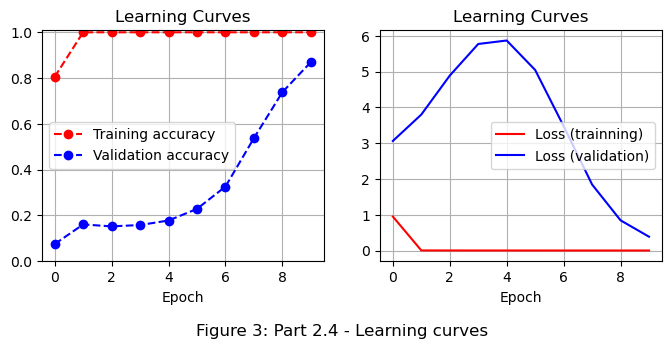

```python
# Obtaining metric data
print("The improvement over the 5 epochs")
cnn_history_df = pd.DataFrame(cnn_history.history)
#cnn_history_df.index = [range(1,10,1)]
print(cnn_history_df)

# Generating learning curve
fig3 = plt.figure(figsize = [8,3])
## Accuracy learning curves
plt.subplot(1,2,1)
plt.plot(cnn_history_df.index, cnn_history_df['accuracy'], label = "Training accuracy",
        color = 'r', linestyle = 'dashed', marker = 'o')
plt.plot(cnn_history_df.index, cnn_history_df['val_accuracy'], label = "Validation accuracy",
         color = 'b', linestyle = 'dashed', marker = 'o')
plt.xlabel('Epoch')
plt.grid(which = 'major', axis = 'both')
plt.title("Learning Curves")
plt.ylim([0, 1.01])
plt.legend()

## Loss learning curves
plt.subplot(1,2,2)
plt.plot(cnn_history_df.index, cnn_history_df['loss'], label = "Loss (trainning)",
        color = 'r')
plt.plot(cnn_history_df.index, cnn_history_df['val_loss'], label = "Loss (validation)",
        color = 'b')
plt.xlabel('Epoch')
plt.grid(which = 'major', axis = 'both')
plt.title("Learning Curves")
plt.legend()

plt.suptitle("Figure 3: Part 2.4 - Learning curves", x = 0.5, y = -.1)
```

```
Example Softmax output:
 [2.20550615e-13 8.58247073e-09 9.99988079e-01 9.36929774e-14
 8.08475988e-07 1.04933086e-07 1.87220053e-08 4.57460458e-12
 1.86391636e-12 1.10104479e-15 1.14142210e-06 1.03980096e-08
 1.03439576e-10 9.65972868e-06 1.54887930e-12 1.47647172e-12
 1.12649033e-13 1.46616352e-09 3.72907962e-08 8.13798735e-13
 7.46723511e-14 9.98450281e-12 1.07360258e-07 4.30939220e-13]
```

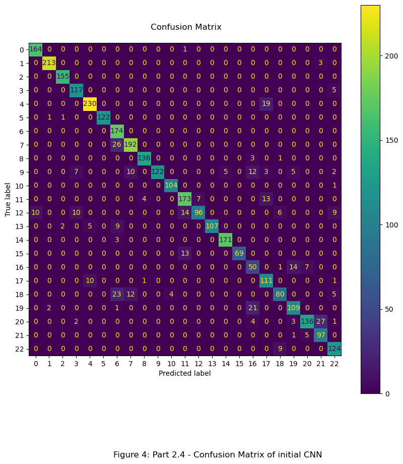

```python
# Predicting classes with the test set
y_pred = cnn_model.predict(x_test, verbose = 0)
print("Example Softmax output:\n", y_pred[0])

# Using softmax values to determine most likely class
y_pred_classes = []
for array in y_pred:
    y_pred_classes.append(np.argmax(array))

# Compling responses into a dataframe
final_results_original = pd.DataFrame({ "True Class":y_test})
final_results_original["Predicted Class"] = y_pred_classes

## Obtaining confusin matrix
summary_confmat = confusion_matrix(final_results_original['True Class'],
                                   final_results_original['Predicted Class'],
                                   labels = range(0, 23))

## Visualizing Matrix
fig, ax = plt.subplots(figsize=(10, 10))
cm_display = ConfusionMatrixDisplay(summary_confmat)
cm_display.plot(ax=ax)
plt.title(" Confusion Matrix\n")
plt.suptitle("Figure 4: Part 2.4 - Confusion Matrix of initial CNN", x = 0.5, y = -0.005)
```

```python
# Evaluating performance of model
print("Evaluate will provide the following:", cnn_model.metrics_names)
loss, accuracy = cnn_model.evaluate(x_test, y_test, verbose = 0)
print("When testing the model on the preprocessed test data:")
print("The loss obtained was", round(loss,3))
print("The the accuracy was", round(accuracy,3))
```

```
Evaluate will provide the following: ['loss', 'accuracy']
When testing the model on the preprocessed test data:
The loss obtained was 0.345
The the accuracy was 0.889
```

# 3. Hyper-parameter optimisation

Take the base network from the previous part and perform separate hyper-parameter optimisation over the following 2 choices. In both cases leave all other configurations constant.

1. Optimise the L2 regularisation on the kernels in all layers. Test the following weight values: 1e-5, 1e-4, 1e-3, 1e-2, 1e-1.

```python
# Defining function to quickly generate model
def model(conv_batchnorm_maxpool_sets, loss, weight):
    ## Initializing
    cnn_model = keras.models.Sequential()
    for element in conv_batchnorm_maxpool_sets:
        # Convolution
        cnn_model.add(keras.layers.Conv2D(filters = element, kernel_size = 3, strides = 1, activation = "relu",
                                          padding = "same", input_shape = [28, 28, 1],
                                          kernel_regularizer = keras.regularizers.l2(weight)))
        # BatchNorm
        cnn_model.add(keras.layers.BatchNormalization())
        # MaxPooling
        cnn_model.add(keras.layers.MaxPooling2D(pool_size = 2))

    # Flattening output
    cnn_model.add(keras.layers.Flatten())
    # Generate output
    cnn_model.add(keras.layers.Dense(24, activation = "softmax"))
    # Compile the model
    cnn_model.compile(optimizer = keras.optimizers.Nadam(learning_rate = 0.01), ###### Nadam optimizer
                      loss = loss,
                      metrics = ['accuracy'])
    return cnn_model

# Checking architecture
cnn_model_original = model([32, 64, 128],'sparse_categorical_crossentropy', 0)
cnn_model_original.summary()
```

```
Model: "sequential_1"
_________________________________________________________________
 Layer (type)                Output Shape              Param #
=================================================================
 conv2d_3 (Conv2D)           (None, 28, 28, 32)        320

 batch_normalization_3 (Batc  (None, 28, 28, 32)       128
 hNormalization)

 max_pooling2d_3 (MaxPooling  (None, 14, 14, 32)       0
 2D)

 conv2d_4 (Conv2D)           (None, 14, 14, 64)        18496

 batch_normalization_4 (Batc  (None, 14, 14, 64)       256
 hNormalization)

 max_pooling2d_4 (MaxPooling  (None, 7, 7, 64)         0
 2D)

 conv2d_5 (Conv2D)           (None, 7, 7, 128)         73856

 batch_normalization_5 (Batc  (None, 7, 7, 128)        512
 hNormalization)

 max_pooling2d_5 (MaxPooling  (None, 3, 3, 128)        0
 2D)

 flatten_1 (Flatten)         (None, 1152)              0

 dense_1 (Dense)             (None, 24)                27672

=================================================================
Total params: 121,240
Trainable params: 120,792
Non-trainable params: 448
_________________________________________________________________
```

```python
# Tunning regularizer hyperparameter
regularisation_weights = [0.00001, 0.0001, 0.001, 0.01, 0.1]
history_dict_l2 = {}

# Looping through regularization weights
for element in regularisation_weights:
    cnn_model_original = model([32, 64, 128],'sparse_categorical_crossentropy', element)

    # Fitting the model on training data and validating
    cnn_history = cnn_model_original.fit(x_train, y_train, epochs = 10, batch_size = 512,
                                         validation_data = (x_val, y_val),verbose = 0,
                                         callbacks = [early_stop, learning_rate_sched_cb])

    # Saving history
    part_3_hist_df = pd.DataFrame(cnn_history.history)
    history_dict_l2[str(element)] = part_3_hist_df
```

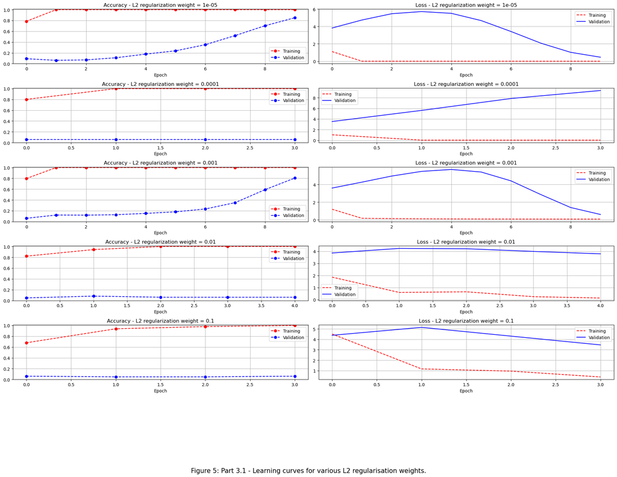

```python
# Plotting the results
position = 1
fig5 = plt.figure(figsize=[20,15])

for l2_weight, df in history_dict_l2.items():
    plt.subplot(6, 2, position)
    # Accuracy
    plt.plot(df.index, df['accuracy'], label = "Training",
            color = 'r', linestyle = 'dashed', marker = 'o')
    plt.plot(df.index, df['val_accuracy'], label = "Validation",
             color = 'b', linestyle = 'dashed',marker = 'o')
    plt.title("Accuracy - L2 regularization weight = " + l2_weight)
    plt.xlabel('Epoch')
    plt.ylim([0, 1.01])
    plt.grid(which = 'major', axis = 'both')
    plt.legend()
    plt.tight_layout()
    position += 1

    # Loss
    plt.subplot(6, 2, position)
    plt.plot(df.index, df['loss'], label = "Training", linestyle = 'dashed',
             color = 'r')
    plt.plot(df.index, df['val_loss'], label = "Validation",
             color = 'b')
    plt.title("Loss - L2 regularization weight = " + l2_weight)
    plt.xlabel('Epoch')
    plt.grid(which = 'major', axis = 'both')
    plt.legend()
    plt.tight_layout()
    position += 1

plt.suptitle("Figure 5: Part 3.1 - Learning curves for various L2 regularisation weights.", size = 15, x = 0.5, y = -.01)
```

```python
# Finding best l2 weight hyperparameter value
best_l2_param = 0
best_accuracy = 0
for l2, df in history_dict_l2.items():
    if df['val_accuracy'].max() > best_accuracy:
        best_l2_param = l2
        best_accuracy = df['val_accuracy'].max()

print("The best parameter based on the accuracy metric in validation was", best_l2_param, "(Accuracy =", best_accuracy,")")
```

```
The best parameter based on the accuracy metric in validation was 1e-05 (Accuracy = 0.849693238735199 )
```

1. Try a different number of layers and layer sizes. In particular do the following: (a) smaller layer sizes (Conv16, Conv32, Conv64); (b) two layers only (Conv32, Conv64); (c) two layers and smaller sizes (Conv16, Conv32)

```python
# Tuning number of convolutional layers (each conv layer comes with an additional batchnorm and maxpooling layers)
layers = [[16,32,64], [32, 64], [16, 32]]
history_dict_conv_layers = {}

# Looping through regularization weights using the best l2 weight obtained above
for element in layers:
    cnn_model = model(element,'sparse_categorical_crossentropy', 0.0001)

    # Fitting the model on training data and validating
    cnn_history = cnn_model.fit(x_train, y_train, epochs = 10, batch_size = 512,
                                validation_data = (x_val, y_val),verbose = 0,
                                callbacks = [early_stop, learning_rate_sched_cb])

    # Saving history
    part_3_hist_df = pd.DataFrame(cnn_history.history)
    history_dict_conv_layers[str(element)] = part_3_hist_df
```

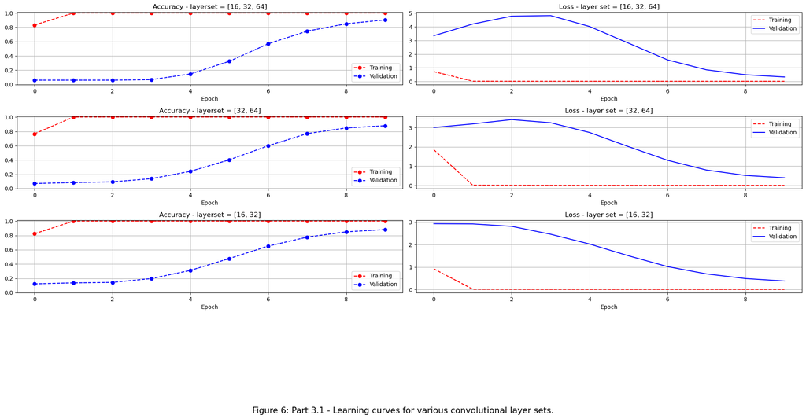

```python
# Plotting the results
position = 1
fig5 = plt.figure(figsize = [20,10])

for layer_set, df in history_dict_conv_layers.items():
    plt.subplot(4, 2, position)
    # Accuracy
    plt.plot(df.index, df['accuracy'], label = "Training",
            color = 'r', linestyle = 'dashed', marker = 'o')
    plt.plot(df.index, df['val_accuracy'], label = "Validation",
             color = 'b', linestyle = 'dashed',marker = 'o')
    plt.title("Accuracy - layerset = " + layer_set)
    plt.xlabel('Epoch')
    plt.ylim([0, 1.01])
    plt.grid(which = 'major', axis = 'both')
    plt.legend()
    plt.tight_layout()
    position += 1

    # Loss
    plt.subplot(4, 2, position)
    plt.plot(df.index, df['loss'], label = "Training", linestyle = 'dashed',
             color = 'r')
    plt.plot(df.index, df['val_loss'], label = "Validation",
             color = 'b')
    plt.title("Loss - layer set = " + layer_set)
    plt.xlabel('Epoch')
    plt.grid(which = 'major', axis = 'both')
    plt.legend()
    plt.tight_layout()
    position += 1

plt.suptitle("Figure 6: Part 3.1 - Learning curves for various convolutional layer sets.", size = 15, x = 0.5, y = -.01)
```

```python
# Finding best convolutional layer architecture
best_architecture = 0
best_accuracy = 0
for sets, df in history_dict_conv_layers.items():
    if df['val_accuracy'].max() > best_accuracy:
        best_architecture = sets
        best_accuracy = df['val_accuracy'].max()

print("The best parameter based on the accuracy metric in validation was", best_architecture, "(Accuracy =",best_accuracy,")")
```

```
The best parameter based on the accuracy metric in validation was [16, 32, 64] (Accuracy = 0.9040713906288147 )
```

1. Display your results as two plots of the performance versus the hyper-parameter value(s). Practice unambiguous and organised visualisation, by labelling the axis, using a legend, title, axis limits and suitable marker and line styles. Make sure to choose the axis limits, such that the important parts of the data are clearly visible.

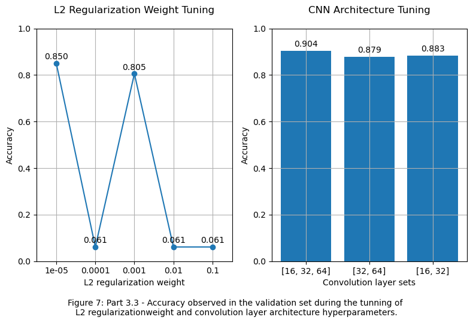

```python
# Obtianing best validation performance from the l2 weight tuning
l2_weight_dict = {}
conver_layers_dict = {}

for weight, df in history_dict_l2.items():
    metric = df.iloc[-1][3]
    l2_weight_dict[weight] = metric

# Obtianing validation performance from the architecture set up tuning
for sets, df in history_dict_conv_layers.items():
    metric = df.iloc[-1][3]
    conver_layers_dict[sets] = metric

# Plotting performance metrics
fig7 = plt.figure(figsize = [8,5])
## l2 weights
plt.subplot(1,2,1)
plt.plot(l2_weight_dict.keys(), l2_weight_dict.values(), marker = 'o')
plt.grid()
plt.title("L2 Regularization Weight Tuning\n")
plt.ylabel("Accuracy")
plt.xlabel("L2 regularization weight")
plt.ylim([0,1])
plt.xlim([-0.5, 4.5])
plt.legend
plt.tight_layout()
for weight, metric in l2_weight_dict.items():
    plt.annotate(f'{metric:.3f}', (weight, metric), textcoords = "offset points", xytext=(0, 5), ha='center')

## Convolution layers
plt.subplot(1,2,2)
plt.bar(conver_layers_dict.keys(), conver_layers_dict.values())
plt.title("CNN Architecture Tuning\n")
plt.ylabel("Accuracy")
plt.xlabel("Convolution layer sets")
plt.legend
plt.tight_layout()
plt.grid()
plt.ylim([0,1])
for sets, metric in conver_layers_dict.items():
    plt.annotate(f'{metric:.3f}', (sets, metric), textcoords = "offset points", xytext=(0, 5), ha='center')

plt.suptitle("Figure 7: Part 3.3 - Accuracy observed in the validation set during the tunning of \nL2 regularization" +
             "weight and convolution layer architecture hyperparameters.", size = 10, x = 0.5, y = -.01)
```

1. Question: What are the best hyper-parameter values to use? Where can we see this in the diagrams and outputs generated above?

##### *Answer*

The L2 Reglarization weight was observed to work best on the validation set at 0.00001, and the convolution architecture that performed best was [16, 32, 64]. This can be observed in figures 5, 6 and 7 where the accuracy against the validation set is visualized. The ideal is to have the smallest difference between the validation accuracy and the training accuracy while also having the highest accuracy. This is the same as saying having the smallest difference between the loss in training and in validation while also having the lowest loss. This situation results in a model that has good accuracy among the options available. The summary plot in figure 7 clearly demonstrates how each model has run on the validation set. If the data is representative, we would exect this to represent the models general accuracy and therefore utility.

# 4. ResNet

In this part you will implement a ResNet version that is similar to the network in section 2. Use the same settings as were used in section 2 in general, but each Conv layer will be replaced by a residual module that, internally, contains two Conv layers. Note that you will need to use the functional form of Keras models for this. An introduction to ResNets is in Module 6.

1. Write a function that builds residual modules with two convolutional layers and a skip connection that adds the input to the output of the second layer, prior to the use of the activation function.

```python
# Creating a new class inheritting from a Keras Layer
class ResidualUnit(keras.layers.Layer):
    # initilizing class
    def __init__(self, filters, strides=1, activation="relu", **kwargs):
        super().__init__(**kwargs)                                             # Puling through arguements of parent class
        self.activation = keras.activations.get(activation)                    # Pulling activation from constructor

        # Setting layers within unit
        self.main_layers = [# First conv Layer
                            keras.layers.Conv2D(filters, 3, strides=strides, padding="same", use_bias=False),
                            keras.layers.BatchNormalization(),
                            keras.layers.MaxPooling2D(pool_size=2),
                            self.activation,
                            #second conv layer
                            keras.layers.Conv2D(filters, 3, strides=strides, padding="same", use_bias=False),
                            keras.layers.BatchNormalization(),
                            keras.layers.MaxPooling2D(pool_size=2)
        ]

        # Skip connection
        self.skip_layers = []
        if strides > 1:
            self.skip_layers = [keras.layers.Conv2D(filters, 1, strides=strides, padding="same", use_bias=False),
                                keras.layers.BatchNormalization()]

# Defining function to pass inputs between units
def call(self, inputs):
    Z = inputs
    # Pass inputs along main path
    for layer in self.main_layers:
        Z = layer(Z)
        skip_Z = inputs
        # pass inputs along skip path
        for layer in self.skip_layers:
            skip_Z = layer(skip_Z)
        return self.activation(Z + skip_Z)
```

1. Build a new network similar to the one from section 2, but replace each convolutional layer in the network with a ResNet module.

```python
# Defining function to generate equivalent ResNet model
def resnet_model(ResNet_layer_sets, loss, weight):
    ## Initializing
    resnet_model = keras.models.Sequential()
    for filters in ResNet_layer_sets:
        # ResNet
        resnet_model.add(ResidualUnit(filters, 1))

    # Flattening output
    resnet_model.add(keras.layers.Flatten())
    # Generate output
    resnet_model.add(keras.layers.Dense(24, activation = "softmax"))
    # Compile the model
    resnet_model.compile(optimizer = keras.optimizers.Nadam(learning_rate = 0.0001),
                         loss = loss,
                         metrics = ['accuracy'])
    return resnet_model

# Creating model
resnet_model = resnet_model([32, 64, 128],'sparse_categorical_crossentropy', 0.01)
```

1. Train this new network the Sign Language dataset.

```python
# Determining optimal batch size
test_range = [16, 32, 45, 64, 128, 256, 512, 1024, 2048]   # Apparently powers of two are more efficient
evaluations = {}
for element in test_range:
    resnet_model_history = resnet_model.fit(x_train, y_train, epochs = 50, batch_size = element,
                                            validation_data = (x_val, y_val), verbose = 0,
                                            callbacks = [early_stop, learning_rate_sched_cb])
    loss, accuracy = resnet_model.evaluate(x_test, y_test, verbose = 0)
    evaluations[element] = accuracy

# Presenting output
pd.DataFrame({'Batch size' : evaluations.keys(), 'Accuracy': evaluations.values()})
```

|  | Batch size | Accuracy |
| --- | --- | --- |
| 0 | 16 | 0.698271 |
| 1 | 32 | 0.700223 |
| 2 | 45 | 0.696877 |
| 3 | 64 | 0.694925 |
| 4 | 128 | 0.693809 |
| 5 | 256 | 0.691021 |
| 6 | 512 | 0.689905 |
| 7 | 1024 | 0.693809 |
| 8 | 2048 | 0.690742 |

```python
# Fitting model
## Batch_size most consistently best between 32 and 64 so I'm using 45
resnet_model_history = resnet_model.fit(x_train, y_train, epochs = 50, batch_size = 45,
                                            validation_data = (x_val, y_val), verbose = 0,
                                            callbacks = [early_stop, learning_rate_sched_cb])
resnet_model.summary()
```

```
Model: "sequential_10"
_________________________________________________________________
 Layer (type)                Output Shape              Param #
=================================================================
 residual_unit (ResidualUnit  (None, 28, 28, 1)        0
 )

 residual_unit_1 (ResidualUn  (None, 28, 28, 1)        0
 it)

 residual_unit_2 (ResidualUn  (None, 28, 28, 1)        0
 it)

 flatten_10 (Flatten)        (None, 784)               0

 dense_10 (Dense)            (None, 24)                18840

=================================================================
Total params: 18,840
Trainable params: 18,840
Non-trainable params: 0
_________________________________________________________________
```

1. Display your learning curves and final performance results.

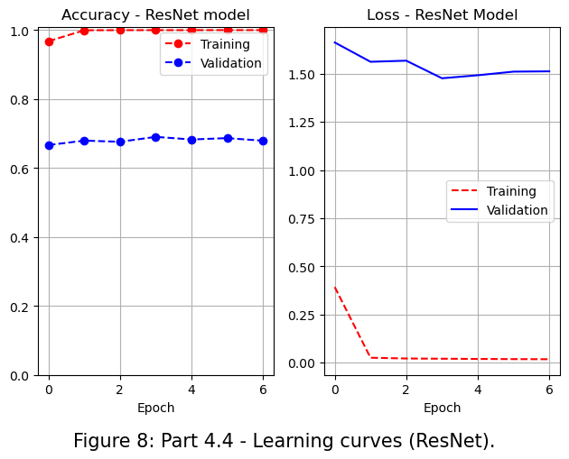

```python
# Saving history
part_4_hist_df = pd.DataFrame(resnet_model_history.history)
#part_3_hist_df.index = [1,2,3,4,5,6,7,8,9,10]

#cPlotting learning curves
plt.subplot(1, 2, 1)
## Accuracy
plt.plot(part_4_hist_df.index, part_4_hist_df['accuracy'], label = "Training",
            color = 'r', linestyle = 'dashed', marker = 'o')
plt.plot(part_4_hist_df.index, part_4_hist_df['val_accuracy'], label = "Validation",
             color = 'b', linestyle = 'dashed',marker = 'o')
plt.title("Accuracy - ResNet model")
plt.xlabel('Epoch')
plt.grid(which = 'major', axis = 'both')
plt.legend()
plt.tight_layout()
plt.ylim([0, 1.01])

## Loss
plt.subplot(1, 2, 2)
plt.plot(part_4_hist_df.index, part_4_hist_df['loss'], label = "Training", linestyle = 'dashed',
             color = 'r')
plt.plot(part_4_hist_df.index, part_4_hist_df['val_loss'], label = "Validation",
             color = 'b')
plt.title("Loss - ResNet Model")
plt.xlabel('Epoch')
plt.grid(which = 'major', axis = 'both')
plt.legend()
plt.tight_layout()

plt.suptitle("Figure 8: Part 4.4 - Learning curves (ResNet).", size = 15, x = 0.5, y = -.01)
```

```
Example Softmax output:
 [3.4560999e-34 2.8242888e-17 1.0000000e+00 3.1254048e-24 3.2645476e-14
 3.6746445e-15 2.1445256e-19 2.4127799e-22 6.9041777e-27 2.0283430e-28
 1.0021543e-14 8.8442240e-21 4.1775909e-27 1.3941708e-12 8.3412364e-31
 2.2844147e-32 4.8331723e-25 2.1877778e-23 4.1501448e-19 8.4540305e-23
 1.3083273e-22 8.4714436e-20 5.4277615e-18 2.0278669e-32]
```

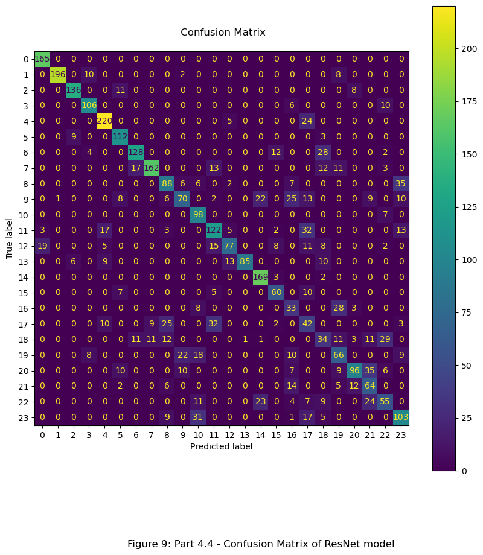

```python
# Predicting classes with the test set
y_pred = resnet_model.predict(x_test, verbose = 0)
print("Example Softmax output:\n", y_pred[0])

# Using softmax values to determine most likely class
y_pred_classes = []
for array in y_pred:
    y_pred_classes.append(np.argmax(array))

# Compling responses into a dataframe
final_results = pd.DataFrame({ "True Class":y_test})
final_results["Predicted Class"] = y_pred_classes

## Obtaining confusin matrix
summary_confmat = confusion_matrix(final_results['True Class'],
                                   final_results['Predicted Class'],
                                   labels = range(0,24))

## Visualizing Matrix
fig, ax = plt.subplots(figsize=(10, 10))
cm_display = ConfusionMatrixDisplay(summary_confmat)
cm_display.plot(ax=ax)
plt.title(" Confusion Matrix\n")
plt.suptitle("Figure 9: Part 4.4 - Confusion Matrix of ResNet model", x = 0.5, y = -0.005)
```

```python
# Evaluating performance of model
print("Evaluate will provide the following:", resnet_model.metrics_names)
loss, accuracy = resnet_model.evaluate(x_test, y_test, verbose = 0)
print("When testing the model on the preprocessed test data:")
print("The loss obtained was", round(loss,3))
print("The accuracy was", round(accuracy,3))
```

```
Evaluate will provide the following: ['loss', 'accuracy']
When testing the model on the preprocessed test data:
The loss obtained was 1.445
The accuracy was 0.694
```

1. Question: What do you conclude about the fitting and the results that you have obtained (i.e. is the ResNet similar, better or worse than previous networks) and what reason would give for this?

*Answer*

In a typical CNN, the aim is to minimize the residual between the input and the output. To do this effectively the model needs to be able to do two things, retain the inut signal and determine the residual. The concept behind the ResNet is that it is better to let the model focus on determining the residual and transferring the input signal across than to try and juggle both tasks simultaneously. This architecture also enables the model to effectively silence layers that aren't useful by placing more weight on the input signal in the residual unit than the layer its by-passing.

```
Evaluate will provide the following: ['loss', 'accuracy']
When testing the model on the preprocessed test data:
The loss obtained was 3.002
The accuracy was 0.452
```

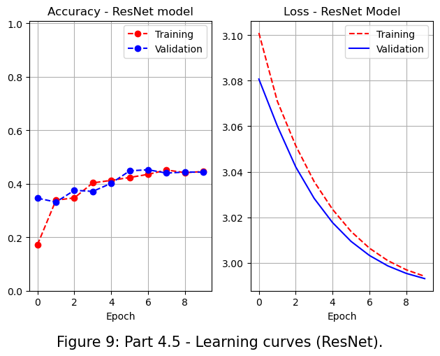

```python
### Extension
train_set2 = pd.read_csv(train_path)
test_set2 = pd.read_csv(test_path)

train_set2.iloc[:,1:] = train_set.iloc[:,1:]/255
test_set2.iloc[:,1:] = test_set.iloc[:,1:]/255

# Setting the labels to be continuous inorder to keep softmax activation and categorical cross entropy loss funtion
label_encoder = LabelEncoder()
train_set2['label'] = label_encoder.fit_transform(train_set2['label'])
test_set2['label'] = label_encoder.fit_transform(test_set2['label'])

# Combine sets, shuffle, and split 80:20 (train and test)
combined = pd.concat([train_set2, test_set2])
shuffled = combined.sample(frac=1).reset_index(drop = True)
x_train_shuffle, x_test_shuffle, y_train_shuffle, y_test_shuffle = train_test_split(shuffled.iloc[:,1:],
                                                                                shuffled['label'],
                                                                                test_size = 0.2,
                                                                                stratify = shuffled['label'],
                                                                                random_state = 1)

# Obtianing validation set (50:50 split of test set as before)
x_test_shuffle, x_val_shuffle, y_test_shuffle, y_val_shuffle = train_test_split(x_test_shuffle,
                                                                                  y_test_shuffle,
                                                                                  test_size = 0.5,
                                                                                  stratify = y_test_shuffle,
                                                                                  random_state = 1)

# Reshaping as required
x_train_shuffle = x_train_shuffle.values.reshape(-1, 28, 28, 1)
x_test_shuffle = x_test_shuffle.values.reshape(-1, 28, 28, 1)
x_val_shuffle = x_val_shuffle.values.reshape(-1, 28, 28, 1)

## Batch_size most consistently best between 32 and 64 so I'm using 45
resnet_model_history = resnet_model.fit(x_train_shuffle, y_train_shuffle, epochs = 50, batch_size = 45,
                                            validation_data = (x_val_shuffle, y_val_shuffle), verbose = 0,
                                            callbacks = [early_stop, learning_rate_sched_cb])
# Saving history
part_4_hist_df = pd.DataFrame(resnet_model_history.history)

# Plotting learning curves
plt.subplot(1, 2, 1)
## Accuracy
plt.plot(part_4_hist_df.index, part_4_hist_df['accuracy'], label = "Training",
            color = 'r', linestyle = 'dashed', marker = 'o')
plt.plot(part_4_hist_df.index, part_4_hist_df['val_accuracy'], label = "Validation",
             color = 'b', linestyle = 'dashed',marker = 'o')
plt.title("Accuracy - ResNet model")
plt.xlabel('Epoch')
plt.grid(which = 'major', axis = 'both')
plt.legend()
plt.tight_layout()
plt.ylim([0, 1.01])

## Loss
plt.subplot(1, 2, 2)
plt.plot(part_4_hist_df.index, part_4_hist_df['loss'], label = "Training", linestyle = 'dashed',
             color = 'r')
plt.plot(part_4_hist_df.index, part_4_hist_df['val_loss'], label = "Validation",
             color = 'b')
plt.title("Loss - ResNet Model")
plt.xlabel('Epoch')
plt.grid(which = 'major', axis = 'both')
plt.legend()
plt.tight_layout()

plt.suptitle("Figure 9: Part 4.5 - Learning curves (ResNet).", size = 15, x = 0.5, y = -.01)

# Evaluating performance of model
print("Evaluate will provide the following:", resnet_model.metrics_names)
loss, accuracy = resnet_model.evaluate(x_test_shuffle, y_test_shuffle, verbose = 0)
print("When testing the model on the preprocessed test data:")
print("The loss obtained was", round(loss,3))
print("The accuracy was", round(accuracy,3))
```

Shuffling the data lead to lower accuracy, but the model performs as well on the training set as it does the validation set and test set. This provides further evidence the original training set must have gone through a few manipulations to improve its generalizability, on kaggle they mention a few manipulations but it is unclear if these were also completed on the test set or if the test set is a completely seperate sample. In any case, the ResNet model appears to be picking up complex patterns that arise from that manipualtion process result.

Lets attempt this again just using the training set data:

```
Evaluate will provide the following: ['loss', 'accuracy']
When testing the model on the preprocessed test data:
The loss obtained was 2.778
The accuracy was 0.47
```

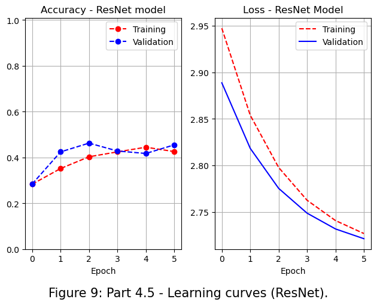

```python
### Extension
train_set3 = pd.read_csv(train_path)

train_set3.iloc[:,1:] = train_set.iloc[:,1:]/255

# Setting the labels to be continuous inorder to keep softmax activation and categorical cross entropy loss funtion
label_encoder = LabelEncoder()
train_set3['label'] = label_encoder.fit_transform(train_set3['label'])

# Split training set 80:20 (train and test)
x_train_shuffle, x_test_shuffle, y_train_shuffle, y_test_shuffle = train_test_split(train_set3.iloc[:,1:],
                                                                                    train_set3['label'],
                                                                                    test_size = 0.2,
                                                                                    stratify = train_set3['label'],
                                                                                    random_state = 2)

# Obtianing validation set (50:50 split of test set as before)
x_test_shuffle, x_val_shuffle, y_test_shuffle, y_val_shuffle = train_test_split(x_test_shuffle,
                                                                                y_test_shuffle,
                                                                                test_size = 0.5,
                                                                                stratify = y_test_shuffle,
                                                                                random_state = 1)

# Reshaping as required
x_train_shuffle = x_train_shuffle.values.reshape(-1, 28, 28, 1)
x_test_shuffle = x_test_shuffle.values.reshape(-1, 28, 28, 1)
x_val_shuffle = x_val_shuffle.values.reshape(-1, 28, 28, 1)

## Batch_size most consistently best between 32 and 64 so I'm using 45
resnet_model_history = resnet_model.fit(x_train_shuffle, y_train_shuffle, epochs = 50, batch_size = 45,
                                            validation_data = (x_val_shuffle, y_val_shuffle), verbose = 0,
                                            callbacks = [early_stop, learning_rate_sched_cb])
# Saving history
part_4_hist_df = pd.DataFrame(resnet_model_history.history)

# Plotting learning curves
plt.subplot(1, 2, 1)
## Accuracy
plt.plot(part_4_hist_df.index, part_4_hist_df['accuracy'], label = "Training",
            color = 'r', linestyle = 'dashed', marker = 'o')
plt.plot(part_4_hist_df.index, part_4_hist_df['val_accuracy'], label = "Validation",
             color = 'b', linestyle = 'dashed',marker = 'o')
plt.title("Accuracy - ResNet model")
plt.xlabel('Epoch')
plt.grid(which = 'major', axis = 'both')
plt.legend()
plt.tight_layout()
plt.ylim([0, 1.01])

## Loss
plt.subplot(1, 2, 2)
plt.plot(part_4_hist_df.index, part_4_hist_df['loss'], label = "Training", linestyle = 'dashed',
             color = 'r')
plt.plot(part_4_hist_df.index, part_4_hist_df['val_loss'], label = "Validation",
             color = 'b')
plt.title("Loss - ResNet Model")
plt.xlabel('Epoch')
plt.grid(which = 'major', axis = 'both')
plt.legend()
plt.tight_layout()

plt.suptitle("Figure 9: Part 4.5 - Learning curves (ResNet).", size = 15, x = 0.5, y = -.01)

# Evaluating performance of model
print("Evaluate will provide the following:", resnet_model.metrics_names)
loss, accuracy = resnet_model.evaluate(x_test_shuffle, y_test_shuffle, verbose = 0)
print("When testing the model on the preprocessed test data:")
print("The loss obtained was", round(loss,3))
print("The accuracy was", round(accuracy,3))
```

The model performs no better based on the accuracy metric. However, there are less obvious signs of overfitting when compared to the original ResNet model over the same epoch domain.

The model may perform better if it had a deeper architecture or more samples as is more typical of ResNet models.

# 5. Final evaluation

1. Choose the best network (from all the options you have explored above in sections 2, 3 and 4) and explain your reasons, and then evaluate the final performance results

```python
# Evaluating performance of model
print("Evaluate will provide the following:", cnn_model.metrics_names)
loss, accuracy = cnn_model.evaluate(x_test, y_test, verbose = 0)
print("When testing the model on the preprocessed test data:")
print("The loss obtained was", round(loss,3))
print("The the accuracy was", round(accuracy,3))
```

```
Evaluate will provide the following: ['loss', 'accuracy']
When testing the model on the preprocessed test data:
The loss obtained was 0.345
The the accuracy was 0.889
```

1. Calculate the confusion matrix and show the matrix graphically

```
Example Softmax output:
 [1.6613747e-15 2.5543103e-09 9.9950874e-01 2.3542034e-14 3.8277402e-11
 4.2491224e-09 9.7222763e-09 5.2402765e-12 3.1249020e-19 6.6389080e-14
 2.8245986e-09 1.6144914e-11 2.1528911e-12 4.9120840e-04 2.2949600e-12
 5.5038069e-10 8.4826236e-16 7.3850006e-12 2.8386586e-08 1.3497203e-14
 9.3307125e-15 1.9098101e-15 2.1167869e-08 4.8338752e-18]
```

```
<keras.engine.sequential.Sequential at 0x1bd408f0760>
```

[figure not shown]

```python
# Predicting classes with the test set
y_pred = cnn_model_original.predict(x_test, verbose = 0)
print("Example Softmax output:\n", y_pred[0])

# Using softmax values to determine most likely class
y_pred_classes = []
for array in y_pred:
    y_pred_classes.append(np.argmax(array))

# Compling responses into a dataframe
final_results_original = pd.DataFrame({ "True Class":y_test})
final_results_original["Predicted Class"] = y_pred_classes

## Obtaining confusin matrix
summary_confmat = confusion_matrix(final_results_tuned['True Class'],
                                   final_results_tuned['Predicted Class'],
                                   labels = range(0, 24))

## Visualizing Matrix
fig, ax = plt.subplots(figsize=(10, 10))
cm_display = ConfusionMatrixDisplay(summary_confmat)
cm_display.plot(ax=ax)
plt.title(" Confusion Matrix\n")
plt.suptitle("Figure 10: Part 5.2 - Confusion Matrix of tuned CNN", x = 0.5, y = -0.005)
cnn_model
```

1. Question: Which class is most often incorrectly classified? Explaining your reasoning.

```python
# Confusion Matrix - Multiclass
multiclass_confmat = multilabel_confusion_matrix(final_results_original['True Class'],
                                                 final_results_original['Predicted Class'],
                                                 labels = range(0,24))
# Obtaining incorrect classification counts
false_positive = {}
false_negative = {}
class_label = 0
for class_cm in multiclass_confmat:
    false_positive[class_label] = class_cm[0,1]
    false_negative[class_label] = class_cm[1,0]
    class_label +=1

inaccuracy_counts = pd.DataFrame({"False Positive": false_positive, 'False Negative': false_negative})
inaccuracy_counts["Total Inaccuracies"] = inaccuracy_counts["False Positive"] + inaccuracy_counts["False Negative"]
inaccuracy_counts
```

|  | False Positive | False Negative | Total Inaccuracies |
| --- | --- | --- | --- |
| 0 | 6 | 0 | 6 |
| 1 | 30 | 10 | 40 |
| 2 | 0 | 14 | 14 |
| 3 | 6 | 21 | 27 |
| 4 | 10 | 22 | 32 |
| 5 | 0 | 5 | 5 |
| 6 | 26 | 18 | 44 |
| 7 | 79 | 7 | 86 |
| 8 | 4 | 18 | 22 |
| 9 | 29 | 22 | 51 |
| 10 | 4 | 1 | 5 |
| 11 | 9 | 7 | 16 |
| 12 | 0 | 28 | 28 |
| 13 | 0 | 34 | 34 |
| 14 | 8 | 0 | 8 |
| 15 | 2 | 0 | 2 |
| 16 | 25 | 8 | 33 |
| 17 | 9 | 18 | 27 |
| 18 | 26 | 52 | 78 |
| 19 | 86 | 0 | 86 |
| 20 | 1 | 90 | 91 |
| 21 | 27 | 8 | 35 |
| 22 | 20 | 12 | 32 |
| 23 | 16 | 28 | 44 |

```python
# Demonstrating errors
## False Negative
instances_of_21 = final_results_original[final_results_original["True Class"] == 20]
incorrect_instances = instances_of_21[instances_of_21["Predicted Class"] != 20]
incorrect_instances_df = pd.DataFrame(incorrect_instances["Predicted Class"].value_counts())
label = [("class " + str(x)) for x in incorrect_instances_df.index]

## False Positive
instances_of_other = final_results_original[final_results_original["True Class"] != 20]
incorrect_classification = instances_of_other[instances_of_other["Predicted Class"] == 20]
incorrect_classification_df = pd.DataFrame(incorrect_classification["True Class"].value_counts())
label_1 = [("class " + str(x)) for x in incorrect_classification_df.index]
```

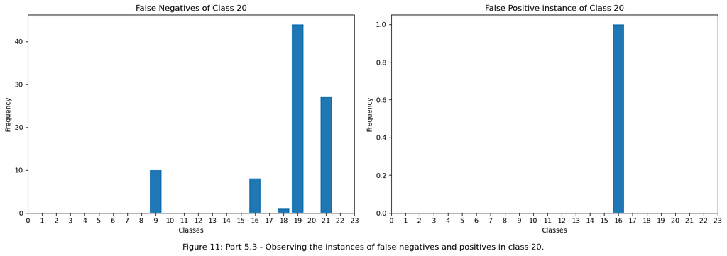

```python
# Plotting
fig9 = plt.figure(figsize = [15,5])
plt.subplot(1,2,1)
plt.bar(incorrect_instances_df.index, incorrect_instances_df["Predicted Class"])
plt.title("False Negatives of Class 20")
plt.xticks([0,1,2,3,4,5,6,7,8,9,10,11,12,13,14,15,16,17,18,19,20,21,22,23])
plt.xlabel("Classes")
plt.ylabel("Frequency")
plt.tight_layout()

plt.subplot(1,2,2)
plt.bar(incorrect_classification_df.index, incorrect_classification_df["True Class"])
plt.title("False Positive instance of Class 20")
plt.xticks([0,1,2,3,4,5,6,7,8,9,10,11,12,13,14,15,16,17,18,19,20,21,22,23])
plt.xlabel("Classes")
plt.ylabel("Frequency")
plt.tight_layout()
plt.suptitle("Figure 11: Part 5.3 - Observing the instances of false negatives and positives in class 20.",
             x = 0.5, y = -.01)
```

*Answer*

[figure not shown]

```python
## displaying first instance of each class
position = 3
plt.figure(figsize = [10, 3])
for class_, index in samples.items():
    if class_ in [21]:
        plt.subplot(1,8,1)
        plt.imshow(train_set.iloc[index, 1:].values.reshape(28,28), cmap='gray')
        plt.grid(False)
        plt.title("V")
        plt.tight_layout()
    elif class_ in [10, 16, 19, 20, 22]: # adding one to every number 9 or higher so they line up
        plt.subplot(1, 8, position)
        plt.imshow(train_set.iloc[index, 1:].values.reshape(28,28), cmap='gray')
        plt.grid(False)
        plt.tight_layout()
        if class_ == 10:
            plt.title('K')
        if class_ == 16:
            plt.title('R')
        if class_ == 19:
            plt.title('T')
        if class_ == 20:
            plt.title('U')
        if class_ == 22:
            plt.title('W')
        position += 1

plt.suptitle("Figure 12: Part 5.3 - Image comparisson between 'U' ands it's most common false negatives.", x = 0.5, y = 0)
```